# Lab 6

```r
library(tidytext)
library(tidyverse)
library(dplyr)
library(ggplot2)
library(readr)
library(DT)
```

```r
mt_samples <- read_csv("https://raw.githubusercontent.com/USCbiostats/data-science-data/master/00_mtsamples/mtsamples.csv")
```

```
──────────────────────────────────────────────────────── Delimiter: "," chr
(5): description, medical_specialty, sample_name, transcription, keywords dbl
(1): ...1
```

```r
mt_samples <- mt_samples |>
  select(description, medical_specialty, transcription)

head(mt_samples)
```

```
# A tibble: 6 × 3
  description                                    medical_specialty transcription
  <chr>                                          <chr>             <chr>
1 A 23-year-old white female presents with comp… Allergy / Immuno… "SUBJECTIVE:…
2 Consult for laparoscopic gastric bypass.       Bariatrics        "PAST MEDICA…
3 Consult for laparoscopic gastric bypass.       Bariatrics        "HISTORY OF …
4 2-D M-Mode. Doppler.                           Cardiovascular /… "2-D M-MODE:…
5 2-D Echocardiogram                             Cardiovascular /… "1.  The lef…
6 Morbid obesity.  Laparoscopic antecolic anteg… Bariatrics        "PREOPERATIV…
```

# 1. What specialties do we have?

```r
mt_samples |>
  count(medical_specialty, sort = TRUE) |>
  datatable(
    options = list(pageLength = 10)
  )
```

|  | medical_specialty | n |
| --- | --- | --- |
| 1 | Surgery | 1103 |
| 2 | Consult - History and Phy. | 516 |
| 3 | Cardiovascular / Pulmonary | 372 |
| 4 | Orthopedic | 355 |
| 5 | Radiology | 273 |
| 6 | General Medicine | 259 |
| 7 | Gastroenterology | 230 |
| 8 | Neurology | 223 |
| 9 | SOAP / Chart / Progress Notes | 166 |
| 10 | Obstetrics / Gynecology | 160 |

[output cut: 30 more lines]

There are 40 different categories under the medical_specialty column. Most of the categories are medical specialties. Some of the categories are not linked to a specialty and are just describing the type of medical document (e.g. “Consult - History and Phy.”, “SOAP / Chart / Progress Notes”, “Discharge Summary”, “Emergency Room Reports”). The categories are not evenly distributed. Surgery is by far the most represented specialty in this dataset.

# 2. Tokenize the words and visualize.

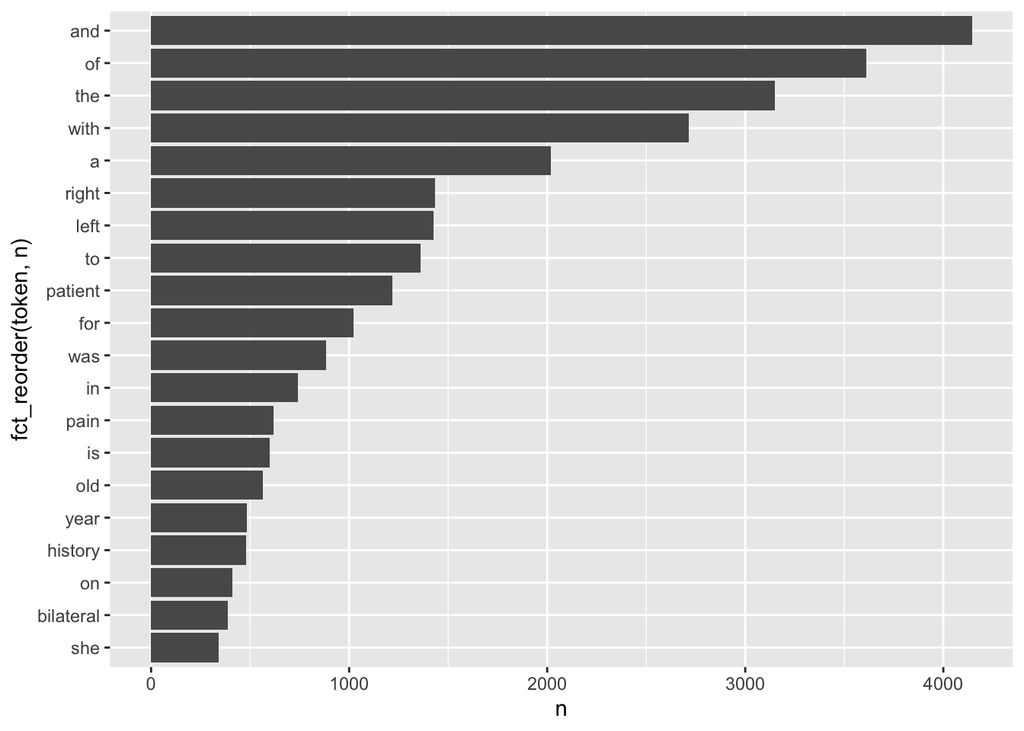

```r
library(forcats)

mt_samples |>
  unnest_tokens(token, description) |>
  count(token) |>
  top_n(20, n) |>
  ggplot(aes(n,fct_reorder(token, n))) +
  geom_col()
```

Many of the top 20 most common words in the description are stop words (e.g. “and”, “of”, “the”). The other words make sense. There are direction words (“left”, right”, “bilateral”) to specify which side of the body is affected. The other words, such as “patient”, “year”, “old”, and “history” are often used in the opening line of a description (“Patient is a X year old woman, with history of x”). Pain is a common complaint.

# 3. Redo visualization, removing stopwords.

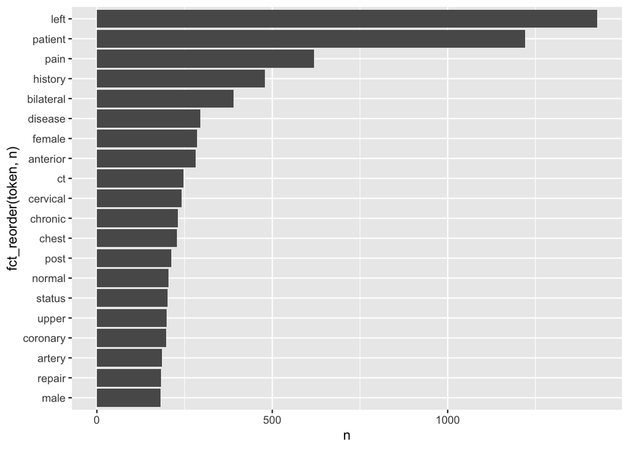

```r
mt_samples |>
  unnest_tokens(token, description) |>
  anti_join(stop_words, by = c("token" = "word")) |>
  count(token) |>
  top_n(20, n) |>
  ggplot(aes(n,fct_reorder(token, n))) +
  geom_col()
```

We see that they saw more female than male patients. It seems like the text is describing the patient’s medical history or current medical problem. It seems like pain is the most common complaint. Many patients were seen for issues related to their cervical spine, chest, or coronary artery.

# Tokenize into bi-grams.

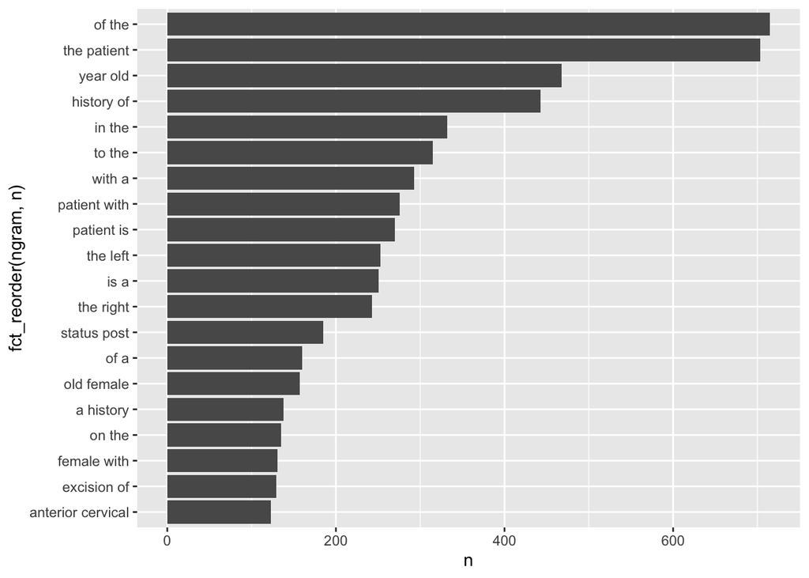

```r
mt_samples |>
  unnest_ngrams(ngram, description, n = 2) |>
  count(ngram) |>
  top_n(20, n) |>
  ggplot(aes(n,fct_reorder(ngram, n))) +
  geom_col()
```

These ngrams make sense given the context, as many of them include the word “patient”. However, these ngrams do not provide much insight into the nature of these visits. Many of these ngrams are combinations of different stop words.

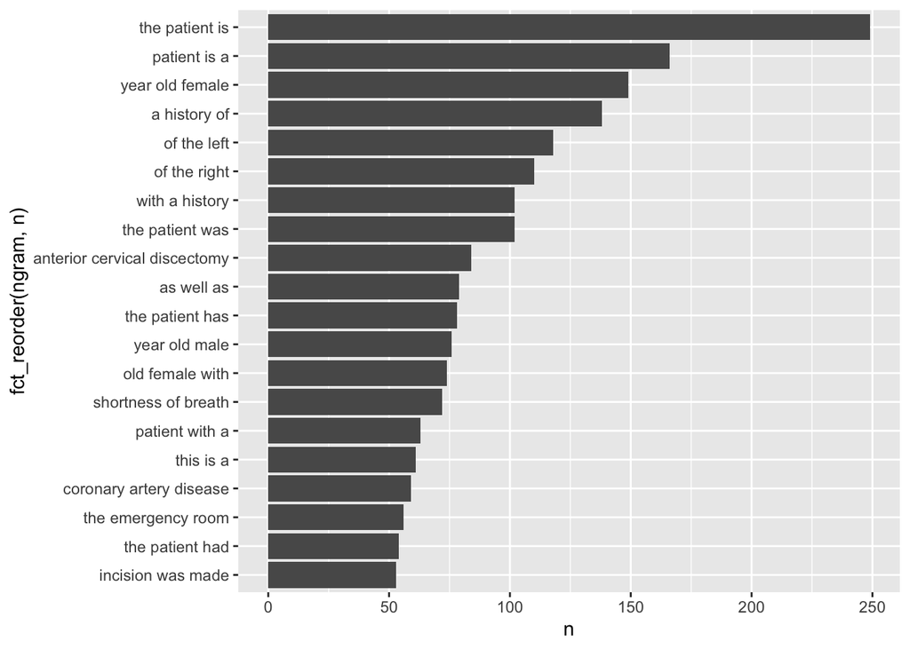

```r
mt_samples |>
  unnest_ngrams(ngram, description, n = 3) |>
  count(ngram) |>
  top_n(20, n) |>
  ggplot(aes(n,fct_reorder(ngram, n))) +
  geom_col()
```

Some of these tri-grams are combinations of the bi-grams, such as “the patient is” and “year old female”. These tri-grams provide more insight into the most common reasons for visit, including “anterior cervical discectomy”, “shortness of breath”, and “coronary artery disease”.

# 5. Pick a word from an bi-gram and count words that appear before and after it

```r
# Words that appear after "left"
mt_samples |>
  unnest_ngrams(ngram, description, n = 2) |>
  separate(ngram, into = c("word1", "word2"), sep = " ") |>
  select(word1, word2) |>
  filter(word1 == "left") |>
  count(word2, sort = TRUE) |>
  datatable(
    options = list(pageLength = 10)
  )
```

|  | word2 | n |
| --- | --- | --- |
| 1 | heart | 61 |
| 2 | knee | 56 |
| 3 | breast | 50 |
| 4 | shoulder | 48 |
| 5 | lower | 43 |
| 6 | foot | 41 |
| 7 | upper | 33 |
| 8 | hip | 32 |
| 9 | anterior | 31 |
| 10 | ventricular | 28 |

[output cut: 199 more lines]

For patients with a complaint on the left side of their body, these are likely the most affected body parts.

```r
# Words that appear before "left"
mt_samples |>
  unnest_ngrams(ngram, description, n = 2) |>
  separate(ngram, into = c("word1", "word2"), sep = " ") |>
  select(word1, word2) |>
  filter(word2 == "left") |>
  count(word1, sort = TRUE) |>
  datatable(
    options = list(pageLength = 10)
  )
```

|  | word1 | n |
| --- | --- | --- |
| 1 | the | 253 |
| 2 | of | 112 |
| 3 | and | 88 |
| 4 | with | 47 |
| 5 | a | 25 |
| 6 | catheterization | 18 |
| 7 | her | 17 |
| 8 | angiography | 16 |
| 9 | to | 16 |
| 10 | his | 15 |

[output cut: 203 more lines]

The words before “left” do not give much insight into patients’ medical conditions, as many preceding words are stop words. However, it seems like catheterizations and angiographies were common procedures.

# 6. Words most used in each of the specialties

```r
mt_samples |>
  unnest_tokens(token, description) |>
  anti_join(stop_words, by = c("token" = "word")) |>
  group_by(medical_specialty) |>
  count(token) |>
  top_n(5, n) |>
  datatable(
    options = list(pageLength = 10)
  )
```

|  | medical_specialty | token | n |
| --- | --- | --- | --- |
| 1 | Allergy / Immunology | allergic | 2 |
| 2 | Allergy / Immunology | allergies | 3 |
| 3 | Allergy / Immunology | asthma | 2 |
| 4 | Allergy / Immunology | elevated | 2 |
| 5 | Allergy / Immunology | female | 2 |
| 6 | Allergy / Immunology | probable | 2 |
| 7 | Autopsy | autopsy | 5 |
| 8 | Autopsy | died | 2 |
| 9 | Autopsy | force | 2 |
| 10 | Autopsy | homicide | 2 |

[output cut: 243 more lines]